# Cahier de suivi Projet Statistique Sujet 23

NEBANGA KANGA-NZANGA Odilon cyrille, GORSE Nathan, THOMASSIN Mathieu

2023-01-29

## 1 To do list

- Revoir modèle de survie et vraisemblance
- Tenter écrire vraisemblance du modèle de guérison (produit des contributions des sujets dans les deux sous-populations)
- Données
- - Utiliser modèle puissance pour analyse données
- - Utiliser modèle de survie après avoir simulé des délais
- $\mathrm{R}$
- dfcrm Code joint
- Fonctions article anais andrillon

### 1 Revoir modèle de survie et vraisemblance

La fonction de survie du modèle de guérison vaut :
$$P(T>=t)=\pi(z) \times S_{U}(T>=t)+1-\pi(z) \qquad (1)$$
où $T$ est le temps d’apparition de la toxicité chez le sujet, $\pi(\cdot)$ est la proportion de sujets ayant manifesté une toxicité durant la fenêtre d’observation (la proportion de sujets non guéris), $S_U(\cdot)$ est la fonction de survie des sujets non guéris.

### 2 Tenter écrire vraisemblance du modèle de guérison (produit des contributions des sujets dans les deux sous-populations)

Pour écrire la vraisemblance du modèle, il faut distinguer deux cas. Dans le premier cas, on connaît la valeur de T qui n’a pas été censurée. L’individu a par conséquent bien manifesté la toxicité dans la fenêtre [0,t*]. La contribution pour ces individus à la vraisemblance correspond alors à la fonction de densité sachant $U(Y=1)$ soit :
$$f(t_i|x_i)=\pi(x_{i})*f_{U}(t)$$
où $f_U(\cdot)$ est la densité de $T$ chez les sujets non guéris.

A l’inverse, pour les individus n’ayant pas manifesté de toxicité durant cette fenêtre, on ne connaît pas T. Autrement dit, Y=0. Par conséquent, on sait juste que T est supérieure à une certaine valeur. On mobilise par conséquent la fonction de survie donnée dans l’équation (1). La vraisemblance vaut donc :

$$L(X,Y)= \prod_{i=1}^{n} \pi(x_{i}) \times f_{U}(t_{i})^{Y_{i}} \times
S(t_{i}|x_{i})^{1-Y_{i}}$$
$$=\displaystyle \prod_{i=1}^{n} \pi(x_{i}) \times f_{U}(t_{i})^{Y_{i} }
\times \Biggl( S_{U} \left(t_{i} \right)\times\pi \left( x_{i}
\right)+\Bigl( 1-\pi \left( x_{i} \right) \Bigr) \Biggr)^{1-Y_{i}}$$

## 3 Utiliser modèle puissance pour analyse données

### Utilisation de CRM Installation du package

```r
require(dfcrm)
# help(dfcrm)
```

Nous entrons les données des doses administrées à chaque patient telles qu’indiqués dans la colonne de gauche du tableau suivant.

$$\begin{array}{cc}
\begin{array}{c}
\text { Administrated dose } \\
\left.\mathbf{( m g g ~ m}^{-2} \mathbf{d a y}^{-\mathbf{1}}\right)
\end{array} & \begin{array}{c}
\text { Clinical } \\
\text { response }
\end{array} \\
\hline 0.5 & \text { NT NT NT } \\
3 & \text { NT NT T } \\
5 & \text { NT NT T } \\
5 & \text { NT NT NT } \\
5 & \text { NT T NT } \\
5 & \text { T NT T } \\
\hline
\end{array}$$

```r
vecteur_dose<-c(rep(0.5,3),rep(3,3),rep(5,4*3))
```

Puis les données de l’effet du traitement sur chaque patient (“Clinical response”).

```r
vecteur_reponse<-c(rep(0,3),0,0,1,0,0,1,rep(0,3),0,1,0,1,0,1)
```

Nous indiquons les doses administrées.

```r
nom_dose<-c("0.5","1","3","5","6")
```

Nous faisons un dataframe reliant ces deux vecteurs.

```r
valeurs_dose_toxicite<-cbind.data.frame(vecteur_dose,vecteur_reponse)
```

Nous entrons les valeurs de probabilités de toxicité des doses a priori fournies par le tableau suivant:

$$\begin{array}{ccccccccc}
\hline \text{HHT-loading dose } \left(\mathbf{m g ~ m}^{-2}\right. day
\left.^{-1}\right) & 0.5 & 1 & 3 & 5 & 6\\
\hline \text {Initial guesses of toxicity probability } & 0.05 &
0.1 & 0.15 & 0.33 & 0.50\\
\hline
\end{array}$$

```r
prior_probabilities <- c(0.05,0.1,0.15,0.33,0.5)
```

Nous assignons la valeur de toxicité limitante (Dose Limiting Toxicity)

```r
p <- 0.33
```

Nous appliquons la fonction crm aux données, avec le modèle puissance et affichons les données

```r
infos<-crm(prior=prior_probabilities,target=p,vecteur_reponse,vecteur_dose,18) # puissance avec empiric
infos
```

```
## Today:  Sun Jan 29 12:00:34 2023
## DATA SUMMARY (CRM)
## PID   Level   Toxicity    Included
## 1     0.5     0       1
## 2     0.5     0       1
## 3     0.5     0       1
## 4     3   0       1
## 5     3   0       1
## 6     3   1       1
## 7     5   0       1
## 8     5   0       1
## 9     5   1       1
## 10    5   0       1
## 11    5   0       1
## 12    5   0       1
## 13    5   0       1
## 14    5   1       1
## 15    5   0       1
## 16    5   1       1
## 17    5   0       1
## 18    5   1       1
##
## Toxicity probability update (with 90 percent probability interval):
## Level     Prior   n   total.wts   total.tox   Ptox    LoLmt   UpLmt
## 1     0.05    0   0       0       0.003   0   0.038
## 2     0.1     0   0       0       0.013   0.001   0.081
## 3     0.15    3   3       1       0.027   0.002   0.126
## 4     0.33    0   0       0       0.122   0.026   0.298
## 5     0.5     12      12          4       0.269   0.102   0.469
## Next recommended dose level: 5
## Recommendation is based on a target toxicity probability of 0.33
##
## Estimation details:
## Empiric dose-toxicity model: p = dose^{exp(beta)}
## dose = 0.05 0.1 0.15 0.33 0.5
## Normal prior on beta with mean 0 and variance 1.34
## Posterior mean of beta: 0.64
## Posterior variance of beta: 0.112
```

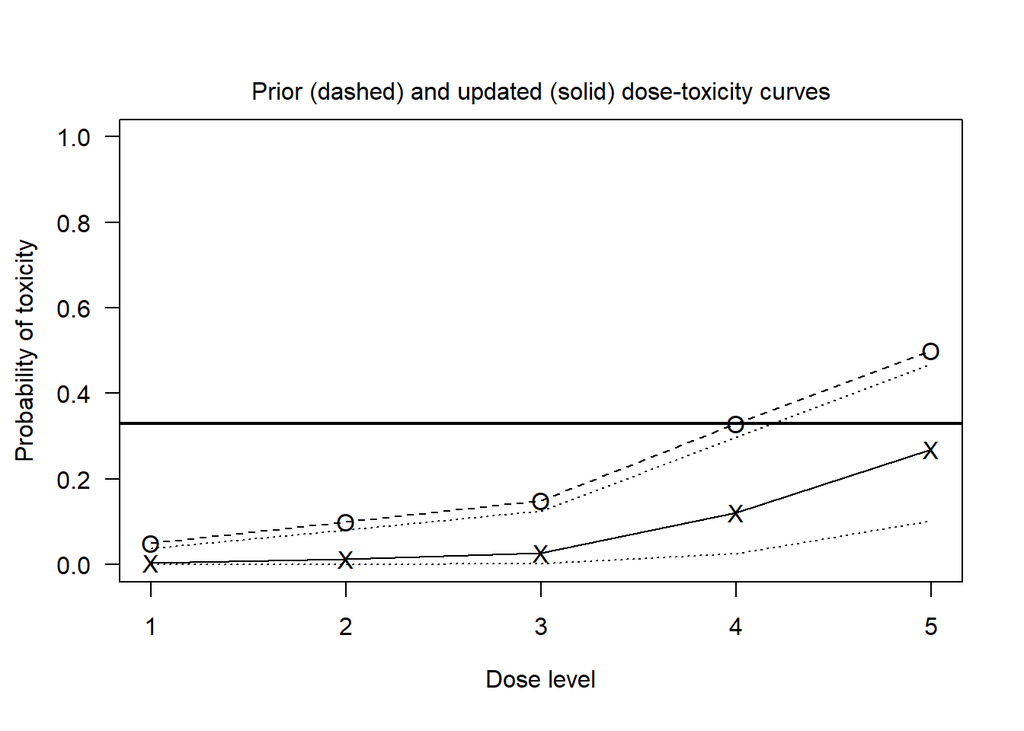

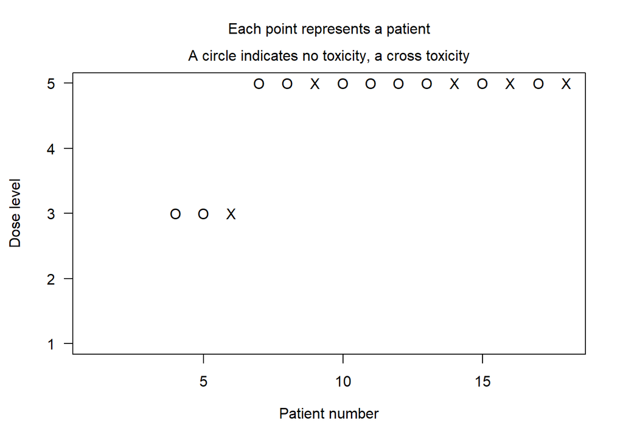

## 4 Utiliser modèle de survie après avoir simulé des délais

```r
#######Modèle de survie logistique.######
###################################
####################

#####I) Simulation des donnees et import des donnees simulees.######
#####On utilise le code fourni pour générer les données.
N=18
res <- titesim(PI=c(0.05, 0.1, 0.15, 0.33, 0.50),
               prior=getprior(0.05, 0.25, 2, 5),
               0.25, N, 1,
               obswin=6,restrict=1,
               rate=3,
               accrual = "poisson", seed=1234)


base_tox <- data.frame(id=1:N, dose=res$level, time_arrival=res$arrival, toxicity.study.time=res$toxicity.study.time, toxicity.time=res$toxicity.time)
head(base_tox)
```

```
##   id dose time_arrival toxicity.study.time toxicity.time
## 1  1    1     5.003517                 Inf           Inf
## 2  2    2     5.016681                 Inf           Inf
## 3  3    2     5.681016                 Inf           Inf
## 4  4    3     6.455381                 Inf           Inf
## 5  5    4     8.103544            9.857439      1.753895
## 6  6    5     9.452727                 Inf           Inf
```

```r
base_tox$toxicity.study.time[base_tox$toxicity.study.time==Inf] <- NA
base_tox$toxicity.time[base_tox$toxicity.time==Inf] <- NA
base_tox$toxicity.study.time <- round(base_tox$toxicity.study.time, 2)
base_tox$toxicity.time <- round(base_tox$toxicity.time, 2)
base_tox$time_arrival <- round(base_tox$time_arrival, 2)
essai_n18 <- base_tox
essai_n18
```

```
##    id dose time_arrival toxicity.study.time toxicity.time
## 1   1    1         5.00                  NA            NA
## 2   2    2         5.02                  NA            NA
## 3   3    2         5.68                  NA            NA
## 4   4    3         6.46                  NA            NA
## 5   5    4         8.10                9.86          1.75
## 6   6    5         9.45                  NA            NA
## 7   7    3        10.97                  NA            NA
## 8   8    4        14.17                  NA            NA
## 9   9    4        20.27                  NA            NA
## 10 10    4        21.51                  NA            NA
## 11 11    4        21.58                  NA            NA
## 12 12    4        23.08                  NA            NA
## 13 13    4        23.11                  NA            NA
## 14 14    5        24.15                  NA            NA
## 15 15    5        25.61               30.45          4.84
## 16 16    5        25.82               27.69          1.87
## 17 17    5        26.31                  NA            NA
## 18 18    5        26.32               29.23          2.91
```

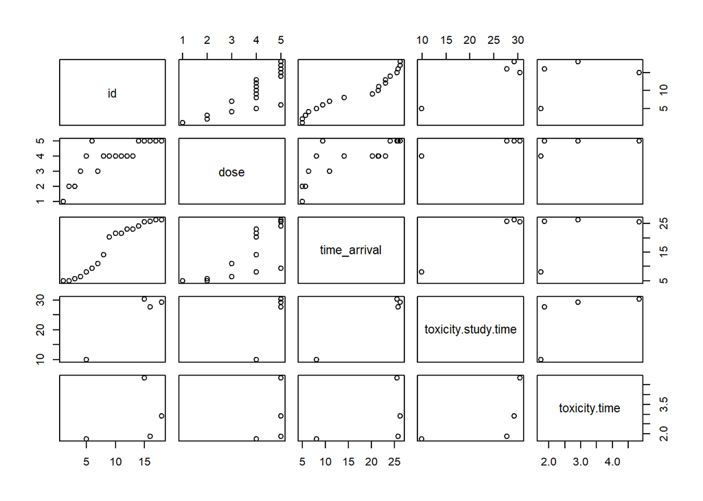

```r
plot(essai_n18)
```

```r
#####On écrit une base de données.
write.table(essai_n18, file="essai_n18.txt", sep="\t", row.names=F)
donnees<-read.table("essai_n18.txt",header=TRUE)

#######II) Creation des arguments de la fonction titecrm. ######

#Vecteur reponse avec reponse=1 si le temps d'apparition de la toxicite est connu.
#Le vecteur reponse vaut 0 sinon.
#Dans notre cas, on donne 0 si le temps d'apparition  de la toxicite est NA.
vecteur_reponse<-ifelse(is.na(donnees$toxicity.time)==FALSE,1,0)

#Les doses administrees à chaque patient sont donnees par la colonne dose.
level_dose<-donnees$dose

#Le nombre de patient correspond au nombre de lignes.
nombre_int=nrow(donnees)

#L'argument weights de la fonction titecrm peut renvoyer au poids donne à chaque individu.
#Comme nous ne sommes pas certains de sa signification à l'heure actuelle, nous donnons un poids uniforme.

#L'autre option serait aussi de prendre en compte la censure
#pour un patient particulier.
poids<-rep(1/nombre_int,nombre_int)

#La date d'arrivee du patient dans l'étude est donnee par la colonne time_arrival.
entree<-donnees$time_arrival

#la date de sortie est donnee par la colonne toxicity.study.time.
sortie<-donnees$toxicity.study.time


######III) Utilisation de la fonction et resume des informations. #####
vue<-titecrm(prior_probabilities,p,model="logistic",tox=vecteur_reponse,dosename=nom_dose,n=nrow(donnees),entry=entree,exit=sortie,level=level_dose,pid=donnees$id,weights =poids)
vue
```

```
## Today:  Sun Jan 29 12:00:34 2023
## DATA SUMMARY (TITE-CRM)
## PID   Level   Toxicity    f/u     Weight      Included
## 1     1   0       N/A     0.056       1
## 2     2   0       N/A     0.056       1
## 3     2   0       N/A     0.056       1
## 4     3   0       N/A     0.056       1
## 5     4   1       N/A     1       1
## 6     5   0       N/A     0.056       1
## 7     3   0       N/A     0.056       1
## 8     4   0       N/A     0.056       1
## 9     4   0       N/A     0.056       1
## 10    4   0       N/A     0.056       1
## 11    4   0       N/A     0.056       1
## 12    4   0       N/A     0.056       1
## 13    4   0       N/A     0.056       1
## 14    5   0       N/A     0.056       1
## 15    5   1       N/A     1       1
## 16    5   1       N/A     1       1
## 17    5   0       N/A     0.056       1
## 18    5   1       N/A     1       1
##
## Toxicity probability update (with 90 percent probability interval):
## Dose          Level   Prior   n   total.wts   total.tox   Ptox    LoLmt   UpLmt
## 0.5   1   0.05    1   0.056       0       0.766   0.059   0.919
## 1     2   0.1     2   0.111       0       0.805   0.114   0.924
## 3     3   0.15    2   0.111       0       0.826   0.168   0.927
## 5     4   0.33    7   1.333       1       0.866   0.354   0.934
## 6     5   0.5     6   3.167       3       0.889   0.522   0.938
## Next recommended dose level: 1
## Recommendation is based on a target toxicity probability of 0.33
##
## Estimation details:
## Logistic dose-toxicity model: p = {1 + exp(-a-exp(beta)*dose)}^{-1} with a = 3
## dose = -5.944 -5.197 -4.735 -3.708 -3
## Normal prior on beta with mean 0 and variance 1.34
## Posterior mean of beta: -1.188
## Posterior variance of beta: 0.496
```

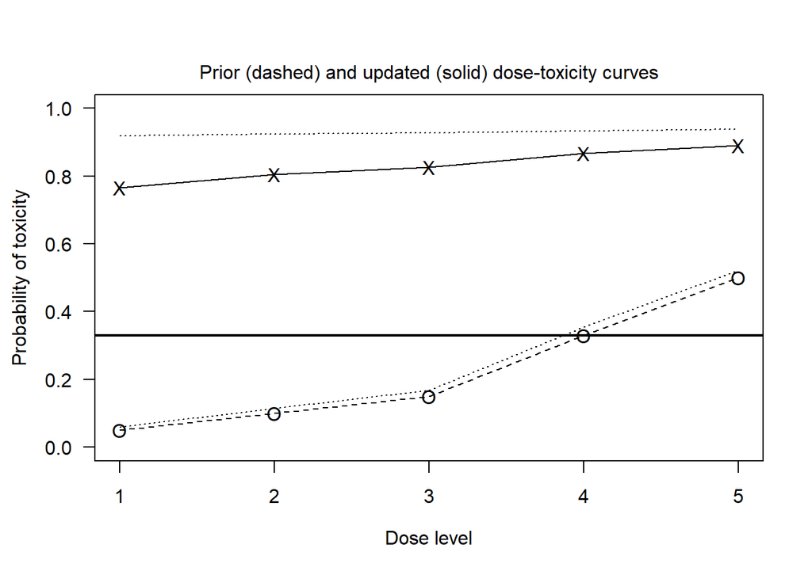

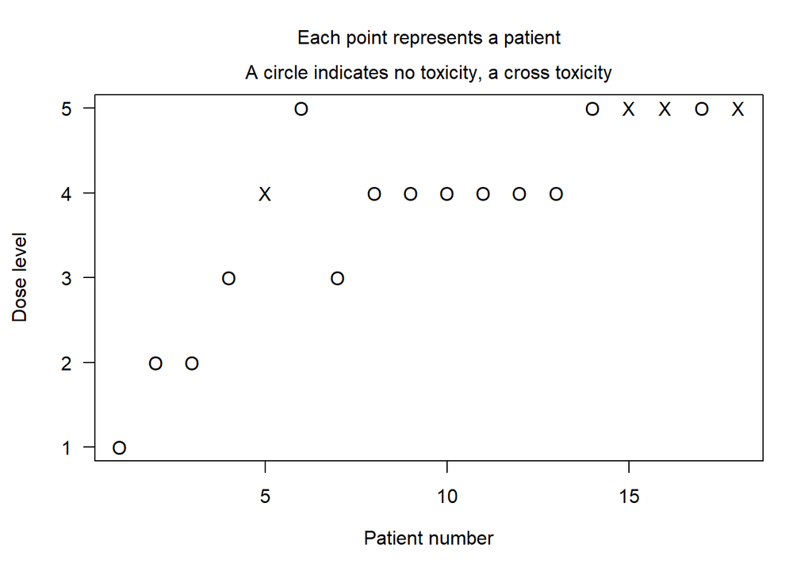

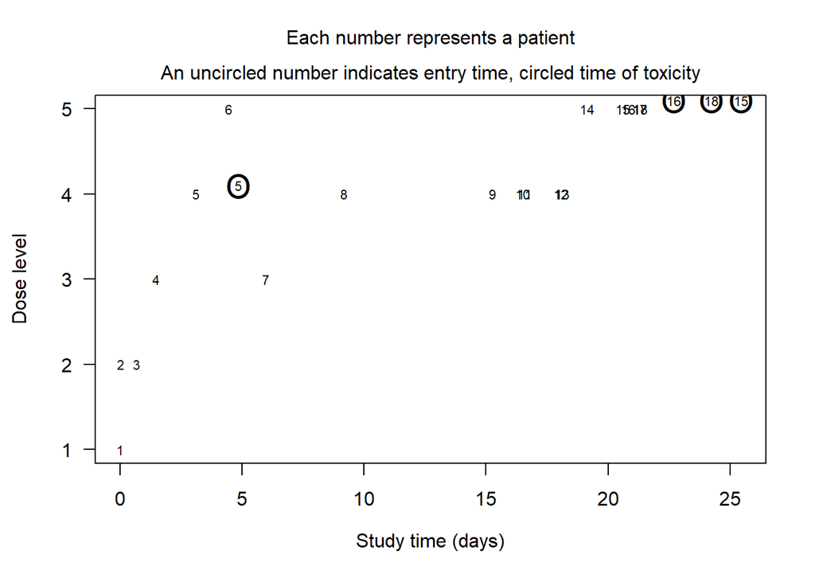

```
##
## No plot output of weight function:
## Times-to-toxicity and censoring times are not available.
```

```r
#####IV) Graphiques. ######
plot.mtd(vue)
```

```r
#######################################
```